# Positional spending and Team Performance Analysis

### Overall project objectives

The National Football League is a professional American football league consisting of 32 teams, divided equally between the National Football Conference and the American Football Conference. NFL Teams spend a lot of money on players in different positions on their roster and want their spending to translate into better performance for their teams therefore creating value for them. In order to understand how these additions will help them, the teams would benefit from an analysis to examine positional spending and its win percentage and then the ability to predict the estimated cap hit of the draft picks across all 32 teams in the NFL from 2013-2018.

At the outset, we are making three hypotheses, posing the following questions: -

1. Does the overall spending (cap hit) of a team impact its win/loss percentage?
2. What is the impact of spending on specific player position groups for the team? (Will my offense or defense define the win percentage during the year in terms of how much we need to spend on them?)
3. If a player with certain demographics is drafted to a particular team, depending on his position how much is he likely to cost the team?

### Dataset description

Method used to get data : Web Scraping.  
Sites Scarped : Spotrac.com, ProFootballReference.com and ESPN.com

From **Spotrac.com** we have extracted data for each team basis the positions of each player, their age, the number of players in that position, the cap value in dollars and the as a percentage of total cap, and the ranking for that position in the NFL for each of the years from 2013-2018.

From **Pro-football-reference**, we have extracted data for all of these years for the same teams, with the number of games they have won, lost and tied, their win percentage, the points scored for and against, the average strength of opposition and their own offensive and defensive quality. Further, for each player in a team, their position, age, height, weight, college and experience i.e. their demographics has been extracted

From **ESPN.com**, we have extracted the win-loss-tie record for home and away for these teams, their record in the division and the conference and their end win/loss streak.

```python
#Import the python packages pandas, numpy, requests, matplotlib.pyplot and statsmodels.api
import pandas as pd
import numpy as np
import requests
import matplotlib.pyplot as plt
import statsmodels.api as sm
import seaborn as sns
```

### Example scraping process

**The first dataset that we scraped were the NFL team standings from 2018 from ESPN.com.**  
The dataset contains the following:  
df - Contains names of 32 teams in the NFL across 2018  
df1 - Contains the team statistics and position in the league across 2018

#### Data cleaning that was identified

- Combining both dataframes to match team names with respective stats
- Remove special characters, extract team abbreviations from team Name and remove inconsistencies.
- Split 'Home','Away','DIV','Conf' columns to get necessary features
- Fixing data type of the columns
- Remove inconsistent columns

```python
#Use requests to state the site
html = requests.get('http://www.espn.com/nfl/standings/_/group/league').content

#Read the site into dataframes stated above
df_list = pd.read_html(html)
df_list
df = df_list[1] # names of teams
df1 = df_list[3] # stats of the teams
print(df.head(3))
print(df1.head(3))
```

```
                           0
0  ** --NONew Orleans Saints
1    * --LARLos Angeles Rams
2  ** --KCKansas City Chiefs
    W  L  T    PCT HOME AWAY  DIV  CONF   PF   PA  DIFF STRK
0  13  3  0  0.813  6-2  7-1  4-2   9-3  504  353   151   L1
1  13  3  0  0.813  7-1  6-2  6-0   9-3  527  384   143   W2
2  12  4  0  0.750  7-1  5-3  5-1  10-2  565  421   144   W1
```

**The second set of data were additional details about the NFL teams for their standings for the years 2013-2018 from Pro-football.com**  
The dataset contained the following:

Tm - The name of the team  
W - The number of wins  
L - The number of losses  
T - The number of ties  
W-L% - The win-loss ratio  
PF - The total points scored  
PA - The total points conceded  
PD - The difference between PF and PD  
MoV - The margin of victory  
SoS - The strength of the schedule  
SRS - Simple Rating System  
OSRS - Offensive SRS  
DSRS - Defensive SRS

#### Data cleaning that was identified

- Eliminating total lines
- Dropping additional columns
- Removing special characters
- Merge AFC and NFC tables
- Split the names to store only the name and not the location due to change in team location
- Change object type where required

```python
#Display sample data before cleaning from site
exampledf2=pd.read_html('https://www.pro-football-reference.com/years/2018/')[0]
exampledf2.head()
```

|  | Tm | W | L | T | W-L% | PF | PA | PD | MoV | SoS | SRS | OSRS | DSRS |
| --- | --- | --- | --- | --- | --- | --- | --- | --- | --- | --- | --- | --- | --- |
| 0 | AFC East | NaN | NaN | NaN | NaN | NaN | NaN | NaN | NaN | NaN | NaN | NaN | NaN |
| 1 | New England Patriots* | 11.0 | 5.0 | 0.0 | 0.688 | 436.0 | 325.0 | 111.0 | 6.9 | -1.8 | 5.2 | 3.1 | 2.1 |
| 2 | Miami Dolphins | 7.0 | 9.0 | 0.0 | 0.438 | 319.0 | 433.0 | -114.0 | -7.1 | -1.7 | -8.8 | -3.6 | -5.2 |
| 3 | Buffalo Bills | 6.0 | 10.0 | 0.0 | 0.375 | 269.0 | 374.0 | -105.0 | -6.6 | -0.3 | -6.9 | -6.3 | -0.6 |
| 4 | New York Jets | 4.0 | 12.0 | 0.0 | 0.250 | 333.0 | 441.0 | -108.0 | -6.8 | -1.1 | -7.8 | -2.0 | -5.9 |

**The third set of data we scraped were the roster for 32 teams from Pro-football-reference.com.**  
The dataset contains the following:  
No - Uniform number  
Age -- Player's age on December 31st of that year  
Pos -- Position  
In player and team season stats, Capitals indicates primary starter. Lower-case means part-time starter. G -- Games played  
GS -- Games started as an offensive or defensive player Numbers are complete for 1920-59 and 1970-present but are incomplete otherwise  
Wt -- Weight in Pounds  
Ht -- Height (ft-inches)  
Yrs -- Experience  
Years the player was/has been in pro football. AV -- Approximate Value.  
Drafted (tm/rnd/yr) --team from where player was drafter/round of pick /year player was drafted .

#### Data cleaning that was identified

- Handling missing values in the columns if necessary
- Remove special characters in the Players Name
- Fixing data type of the columns
- Making height more consistent
- Identifying and retaining the required columns

```python
#Display sample data before cleaning from site
exampledf3=pd.read_html('http://pfref.com/pi/share/ajPT2')[0]
exampledf3.head()
```

|  | No. | Player | Age | Pos | G | GS | Wt | Ht | College/Univ | BirthDate | Yrs | AV | Drafted (tm/rnd/yr) |
| --- | --- | --- | --- | --- | --- | --- | --- | --- | --- | --- | --- | --- | --- |
| 0 | 28.0 | Nnamdi Asomugha | 32.0 | NaN | 3 | 1.0 | 215.0 | 6-3 | California | 7/6/1981 | 10 | 0.0 | Oakland Raiders / 1st / 31st pick / 2003 |
| 1 | 84.0 | Jonathan Baldwin | 24.0 | wr | 7 | 1.0 | 225.0 | 6-4 | Pittsburgh | 8/10/1989 | 2 | 0.0 | Kansas City Chiefs / 1st / 26th pick / 2011 |
| 2 | 81.0 | Anquan Boldin | 33.0 | WR | 16 | 16.0 | 218.0 | 6-1 | Florida St. | 10/3/1980 | 10 | 12.0 | Arizona Cardinals / 2nd / 54th pick / 2003 |
| 3 | 75.0 | Alex Boone | 26.0 | RG | 16 | 16.0 | 330.0 | 6-7 | Ohio St. | 5/4/1987 | 3 | 8.0 | NaN |
| 4 | 53.0 | NaVorro Bowman* | 25.0 | LB | 16 | 16.0 | 230.0 | 6-1 | Penn St. | 3/28/1988 | 3 | 18.0 | San Francisco 49ers / 3rd / 91st pick / 2010 |

**The fourth set of data we scraped were the positional spending for 32 teams from 2013 to 2018 from Spotrac.com.**  
The dataset contains the following:  
Player -- Player's name  
position-- Player's position cap hit -- Overall Salary

#### Data cleaning that was identified

- Handling missing values in the columns if necessary
- Dropping irrelevant columns
- Remove special characters in the Players Name
- Split Player column to get player name and his position
- Fixing data type of the columns

```python
#Display sample data before cleaning from site
exampledf4=pd.read_html('https://www.spotrac.com/nfl/rankings/2013/cap-hit/arizona-cardinals/')[0]
exampledf4.head()
```

|  | Unnamed: 0 | Unnamed: 1 | Player | cap hit |
| --- | --- | --- | --- | --- |
| 0 | 1.0 | NaN | Larry Fitzgerald Wide Receiver | $10,250,000 |
| 1 | 2.0 | NaN | Calais Campbell Defensive End | $8,750,000 |
| 2 | 3.0 | NaN | Darnell Dockett Defensive End | $7,700,000 |
| 3 | 4.0 | NaN | Daryn Colledge Guard | $7,275,000 |
| 4 | 5.0 | NaN | Patrick Peterson Cornerback | $5,026,227 |

**The fifth set of data we scraped were the drafted players from 2013 to 2018 from Pro-football.com.**  
The dataset contains the following:  
Pos -- Position In player and team season stats, Capitals indicates primary starter. Lower-case means part-time starter. Ht -- Height (ft-inches)  
Wt -- Weight in Pounds  
40yd -- Forty yard dash time  
Vertical -- Vertical jump height, in inches  
Bench -- 225 lb bench press reps  
Broad Jump -- Broad jump distance, in inches  
3Cone -- Three cone drill time  
Shuttle -- 20 yard shuttle time  
Drafted (tm/rnd/yr) --team from where player was drafter/round of pick /year player was drafted.

#### Data cleaning that was identified

- Handling missing values in the columns if necessary
- Dropping irrelevent columns
- Remove special characters in the Players Name
- Split Drafted column to extract relevent features
- Fixing data type of the columns

```python
#Display sample data before cleaning from site
exampledf5=pd.read_html('http://www.pro-football-reference.com/draft/2013-combine.htm',match='Combine Results')[0]
exampledf5.head()
```

|  | Player | Pos | School | College | Ht | Wt | 40yd | Vertical | Bench | Broad Jump | 3Cone | Shuttle | Drafted (tm/rnd/yr) |
| --- | --- | --- | --- | --- | --- | --- | --- | --- | --- | --- | --- | --- | --- |
| 0 | Oday Aboushi | OT | Virginia | College Stats | 6-5 | 308 | 5.41 | 23.5 | 17 | 100 | 7.92 | 4.84 | New York Jets / 5th / 141st pick / 2013 |
| 1 | Johnny Adams | CB | Michigan State | College Stats | 5-10 | 185 | 4.48 | NaN | 16 | NaN | NaN | NaN | NaN |
| 2 | Robert Alford | CB | Southeastern Louisiana | NaN | 5-10 | 188 | 4.39 | 40.0 | 17 | 132 | 6.89 | 4.23 | Atlanta Falcons / 2nd / 60th pick / 2013 |
| 3 | Zach Allen | OG | North Carolina State | NaN | 6-2 | 332 | 5.43 | NaN | 32 | NaN | NaN | NaN | NaN |
| 4 | Ryan Allen | P | Louisiana Tech | College Stats | 6-1 | 229 | 4.98 | NaN | NaN | NaN | NaN | NaN | NaN |

# Lets run a sample of our scraping process

We run a sample of our scraped and clean data to show you what was done. Below are the functions we have created and we use the year 2018 for our sample with the Arizona Cardinals team while scraping data.

The below function is designed to scrape data from ESPN.com for NFL that where the raw data obtained will be in the form of a list. It will return a merged dataframe with the standings of the teams for the years that will be inputted in the function. The returned dataframe will have already been cleaned inside the function to remove all inconsistencies.

```python
#defining function data from espn websites to input a list of links and years as input
def web_scraping_espn(url,year):
    final=pd.DataFrame()
    for i in range(len(url)):

        html = requests.get(url[i]).content
        df_list = pd.read_html(html)
        df_list
        df = df_list[1] # names of teams
        df1 = df_list[3] # statistics of the teams
        a=list(df1)
        a
        df_new=pd.DataFrame()
        df_new['team']=df[0]
        #Splitting the details from the statistics into headwise columns of the DataFrame
        df_new[a[0]]=df1[a[0]]
        df_new[a[1]]=df1[a[1]]
        df_new[a[2]]=df1[a[2]]
        df_new[a[3]]=df1[a[3]]
        df_new[a[4]]=df1[a[4]]
        df_new[a[5]]=df1[a[5]]
        df_new[a[6]]=df1[a[6]]
        df_new[a[7]]=df1[a[7]]
        df_new[a[8]]=df1[a[8]]
        df_new[a[9]]=df1[a[9]]
        df_new[a[10]]=df1[a[10]]
        df_new[a[11]]=df1[a[11]]
        df_new['Year']=year[i]
        final=pd.concat([final,df_new])
    # we need to clean the team names and extract TeamShort from the final
    final['TeamShort']=final.team.str.extract('([A-Z]+)[A-Z]')
    final.team=final.team.str.extract('([A-Z][a-z]+\s[A-Za-z]+\s*[0-9]*[A-Za-z]+)')
    final.TeamShort=final.TeamShort.replace(['NO','LAR','KC','CHI','LAC','NE','HOU','BAL','DAL','SEA','IND','PIT','PHI','TEN','MIN','CLE','ATL','WSH','CAR','MIA','GB','DEN','DET','CIN','BUF','NYG','JAX','TB','SF','NYJ','OAK','ARI','SD','STL'],['Saints','Rams','Chiefs','Bears','Chargers','Patriots','Texans','Ravens','Cowboys','Seahawks','Colts','Steelers','Eagles','Titans','Vikings','Browns','Falcons','Redskins','Panthers','Dolphins','Packers','Broncos','Lions','Bengals','Bills','Giants','Jaguars','Buccaneers','49ers','Jets','Raiders','Cardinals','Chargers','Rams'])
    # splitting HOME, AWAY and DIV columns for wins, losses and ties
    final.insert(6,'Home_win',final.HOME.str.split('-',expand=True)[0])
    final.insert(7,'Home_loss',final.HOME.str.split('-',expand=True)[1])
    final.insert(8,'Home_tie',final.HOME.str.split('-',expand=True)[2])
    final.drop(columns='HOME',inplace =True)
    final.insert(8,'Away_win',final.AWAY.str.split('-',expand=True)[0])
    final.insert(9,'Away_loss',final.AWAY.str.split('-',expand=True)[1])
    final.insert(10,'Away_tie',final.AWAY.str.split('-',expand=True)[2])
    final.drop(columns='AWAY',inplace =True)
    final.insert(11,'Div_win',final.DIV.str.split('-',expand=True)[0])
    final.insert(12,'Div_loss',final.DIV.str.split('-',expand=True)[1])
    final.insert(13,'Div_tie',final.DIV.str.split('-',expand=True)[2])
    final.drop(columns='DIV',inplace =True)
    final.insert(13,'Conf_win',final.CONF.str.split('-',expand=True)[0])
    final.insert(14,'Conf_loss',final.CONF.str.split('-',expand=True)[1])
    final.insert(15,'Conf_tie',final.CONF.str.split('-',expand=True)[2])
    final.drop(columns='CONF',inplace =True)
    #Drop columns we will scrape in the next task
    final.drop(['team','W','L','T','PCT','PF','PA','DIFF'],axis=1,inplace=True)

    #resetting index
    final.reset_index(inplace=True)
    final=final.drop('index',axis=1)
    #returns the merged dataframe
    return final
```

```python
#creating a list of links of espn to scrape from
url=['http://www.espn.com/nfl/standings/_/group/league']
#creating a list of years that we are scraping data for as this needs to be incorporated in the dataframe
year=[2018]
```

```python
# Calling the function to scrape and clean the data
team_performance_espn=web_scraping_espn(url,year)
```

The next function is designed to scrape data from Pro-football-refence.com to obtain the details of the performance and standings of the teams from the American Football Conference and the National Football Conference, clean the dataset and output a combined DataFrame of the teams for each of the years.

```python
#Define a function reasite to take in the url and the year of data
def readsite(site,year):
    #Read the site for AFC
    pro_2018_afc=pd.read_html(site)[0]
    #Drop rows which have totals
    pro_2018_afc=pro_2018_afc.drop([0,5,10,15],axis=0)
    #Drop columns with margin of victory and the simple rating system
    pro_2018_afc=pro_2018_afc.drop(['MoV','SRS'],axis=1)
    #Remove special characters
    pro_2018_afc.Tm=pro_2018_afc.Tm.str.rstrip('*')
    pro_2018_afc.Tm=pro_2018_afc.Tm.str.rstrip('+')
    #Add the year of the data
    pro_2018_afc['Year']=year
    #Same steps as above for NFC
    pro_2018_afc.Tm=pro_2018_afc.Tm.astype(str)
    pro_2018_nfc=pd.read_html(site)[1]
    pro_2018_nfc=pro_2018_nfc.drop([0,5,10,15],axis=0)
    pro_2018_nfc=pro_2018_nfc.drop(['MoV','SRS'],axis=1)
    pro_2018_nfc.Tm=pro_2018_nfc.Tm.str.rstrip('*')
    pro_2018_nfc.Tm=pro_2018_nfc.Tm.str.rstrip('+')
    pro_2018_nfc['Year']=year
    pro_2018_nfc.Tm=pro_2018_nfc.Tm.astype(str)
    #Merge the two tables and drop the additonal column
    pro_2018=pd.concat([pro_2018_afc,pro_2018_nfc])
    pro_2018.reset_index(inplace=True)
    pro_2018=pro_2018.drop('index',axis=1)
    return pro_2018
```

```python
#Using readsite download the data for each of the years and merge the table
p_2018=readsite('https://www.pro-football-reference.com/years/2018/','2018')
pro_combined_nfl=pd.concat([p_2018])
pro_combined_nfl.sort_values(by='Year')
pro_combined_nfl.reset_index(inplace=True)
pro_combined_nfl=pro_combined_nfl.drop('index',axis=1)
pro_combined_nfl.Year=pro_combined_nfl.Year.astype(int)
#Re-order the columns and rename them
pro_combined_nfl=pro_combined_nfl[['Year','Tm','W','L','T','W-L%','PF','PA','PD','SoS','OSRS','DSRS']]
pro_combined_nfl=pro_combined_nfl.rename({'Tm':'Team','W':'Win','L':'Loss','T':'Tied','W-L%':'Win/Loss%','PF':'Points For','PA':'Points Against','PD':'Points Differential','SoS':'Opposition Strength','OSRS':'Offense Strength','DSRS':'Defense Strength'},axis='columns')
#Add the short name of the team to remove inconsistencies due to change in location
pro_combined_nfl.insert(2,'TeamShort',pro_combined_nfl.Team.str.split(' ').str[-1])
```

```python
#Merge the two team datasets to get a combined output
total_team_data=pd.merge(pro_combined_nfl,team_performance_espn,how='inner',on=['Year','TeamShort'])
#Handle missing values
total_team_data.replace(np.NaN,0,inplace=True)
total_team_data.head()
```

|  | Year | Team | TeamShort | Win | Loss | Tied | Win/Loss% | Points For | Points Against | Points Differential | ... | Away_win | Away_loss | Away_tie | Div_win | Div_loss | Conf_win | Conf_loss | Conf_tie | Div_tie | STRK |
| --- | --- | --- | --- | --- | --- | --- | --- | --- | --- | --- | --- | --- | --- | --- | --- | --- | --- | --- | --- | --- | --- |
| 0 | 2018 | New England Patriots | Patriots | 11.0 | 5.0 | 0.0 | 0.688 | 436.0 | 325.0 | 111.0 | ... | 3 | 5 | 0 | 5 | 1 | 8 | 4 | 0 | 0 | W2 |
| 1 | 2018 | Miami Dolphins | Dolphins | 7.0 | 9.0 | 0.0 | 0.438 | 319.0 | 433.0 | -114.0 | ... | 1 | 7 | 0 | 4 | 2 | 6 | 6 | 0 | 0 | L3 |
| 2 | 2018 | Buffalo Bills | Bills | 6.0 | 10.0 | 0.0 | 0.375 | 269.0 | 374.0 | -105.0 | ... | 2 | 6 | 0 | 2 | 4 | 4 | 8 | 0 | 0 | W1 |
| 3 | 2018 | New York Jets | Jets | 4.0 | 12.0 | 0.0 | 0.250 | 333.0 | 441.0 | -108.0 | ... | 2 | 6 | 0 | 1 | 5 | 3 | 9 | 0 | 0 | L3 |
| 4 | 2018 | Baltimore Ravens | Ravens | 10.0 | 6.0 | 0.0 | 0.625 | 389.0 | 287.0 | 102.0 | ... | 4 | 4 | 0 | 3 | 3 | 8 | 4 | 0 | 0 | W3 |

5 rows × 26 columns

Our next function aims to obtain the demographic data of Players such as their height, weight, years of experience, age and college. The function scrapes the site, cleans the data, converts the height into inches and adds the name of the team and the year in which the player was on the roster.

```python
#Define function teamlist to take the input of a list of sites for all years and the name of the team
def teamslist (linklist,team):
    #Intialize an empty DataFrame
    df=pd.DataFrame()
    #Initialize year as 2013 because we start scraping data from 2013
    year=2018
    #For loop to clean the data
    for link in linklist:
        #Read teh site link
        df1=pd.read_html(link)[0]
        #Keep only required columns
        df1=df1[['Player','Age','Wt','Ht','Yrs','College/Univ']]
        #Delete the total row
        df1=df1.drop(df1.tail(1).index,axis=0)
        #Remove special characters
        df1.Player=df1.Player.str.rstrip('*')
        #Convert height from feet to inches
        df1['ft']=df1.Ht.str.split('-').str[0]
        df1['point']=df1.Ht.str.split('-').str[1]
        df1['ft']=df1['ft'].astype(float)
        df1['point']=df1['point'].astype(float)
        df1.insert(4,'Ht (Inch)',df1.ft*12+df1.point)
        #Plot Year and Team Name
        df1['Year']=year
        df1['TeamShort']=team
        df1.drop(['Ht','ft','point'],axis=1,inplace=True)
        #Append the data to the data frame
        df=pd.concat([df,df1])
        df.reset_index(inplace=True)
        df=df.drop('index',axis=1)
        #Increase the year by 1
        year+=1
    return(df)
```

We designed another function roster to use teamslist to get a combined roster of all 32 teams for all the years from 2013-2018 from Pro-football-reference.com.

```python
#Roster takes an input of a list of sites for the teams and the names of those teams and runs a loop to extract and merge teh data for all the teams in the list
def roster(teams,teamnames):
    i=0
    df=pd.DataFrame()
    for team in teams:
        df1=teamslist(team,teamnames[i])
        df=pd.concat([df,df1])
        df.reset_index(inplace=True)
        df=df.drop('index',axis=1)
        i+=1
    return df
```

```python
#Identify site links for all teams for player rosters
cardinals=['http://pfref.com/pi/share/EKp4F']
```

```python
#Create a list of team names and the list of sites to be scraped and call the roster function to output the roster fro all teams for all years
allteams=['Cardinals']
all_lists=[cardinals]
total_roster=roster(all_lists,allteams)
total_roster.rename(columns={'Player':'Name'},inplace=True)
```

This function aims to obtain the cap hit of the salaries for each of the players roster from Spotrac.com and store the details with the team name and the year for each cap hit.

```python
#Writing a function to clean all scraped data from 32 teams, for 6 years.
def teamspend (linklist,team):
    year=2018
    df = pd.DataFrame()
    #Run a for loop to clean all the data, eliminate irrelevant columns and merge the dataframes
    for link in linklist:
        spend = pd.read_html(link)[0]
        spend.drop(columns=['Unnamed: 0','Unnamed: 1'],inplace=True)
        Name = []
        for i in spend['Player']:
            Name.append( ' '.join(i.split()[:2]))
        Position = []
        for j in spend['Player']:
            Position.append( ' '.join(j.split()[2:]))
        spend['Name'] = Name
        spend['Position'] = Position
        spend.drop(columns='Player',inplace=True)
        spend['TeamShort'] = team
        spend['Year'] = year
        spend = spend[['TeamShort','Name','Position','cap hit','Year']]
        df=pd.concat([df,spend])
        year+=1
    return(df)
```

```python
#creating list of all the links for the 32 teams of positional spending from 2013-2018
ARI = ['https://www.spotrac.com/nfl/rankings/2018/cap-hit/arizona-cardinals/']
```

```python
#Call the teamspend code for each of the 32 teams
df_ARI=teamspend(ARI,'Cardinals')
```

```python
#creating a combined dataframe for all the teams for overall analysis
Player_spend = pd.DataFrame()
all_teams = [df_ARI]
for team in all_teams:
    Player_spend = pd.concat([Player_spend,team])
#resetting index
Player_spend.reset_index(inplace=True)
Player_spend=Player_spend.drop('index',axis=1)
```

```python
#Cleaning minor changes
#making year to int.
Player_spend['Year'].astype(int,inplace = True)
#removing '$'and',' and converting to integer
Player_spend['cap hit'] = Player_spend['cap hit'].str.replace('([$,])','').astype(int)
```

```python
#Merge the roster from Pro-football-reference.com and Spotrac.com to create a combined dataset
player_database=pd.merge(Player_spend,total_roster,how='inner',on=['Name','Year','TeamShort'])
player_database.head()
```

|  | TeamShort | Name | Position | cap hit | Year | Age | Wt | Ht (Inch) | Yrs | College/Univ |
| --- | --- | --- | --- | --- | --- | --- | --- | --- | --- | --- |
| 0 | Cardinals | Larry Fitzgerald | Wide Receiver | 16850000 | 2018 | 35.0 | 218.0 | 75.0 | 14 | Pittsburgh |
| 1 | Cardinals | Chandler Jones | Defensive End | 15500000 | 2018 | 28.0 | 265.0 | 77.0 | 6 | Syracuse |
| 2 | Cardinals | Patrick Peterson | Cornerback | 14956965 | 2018 | 28.0 | 203.0 | 73.0 | 7 | LSU |
| 3 | Cardinals | Deone Bucannon | Outside Linebacker | 8718000 | 2018 | 26.0 | 211.0 | 73.0 | 4 | Washington St. |
| 4 | Cardinals | Jermaine Gresham | Tight End | 7218750 | 2018 | 30.0 | 260.0 | 77.0 | 8 | Oklahoma |

```python
#Identify missing data in the player database
player_database.isnull().sum()
```

```
TeamShort       0
Name            0
Position        0
cap hit         0
Year            0
Age             0
Wt              0
Ht (Inch)       0
Yrs             0
College/Univ    5
dtype: int64
```

```python
#Delete rows where the College/Univ is missing
player_database=player_database.dropna()
```

```python
#Verifying if null values are handled or not
player_database.isnull().sum()
```

```
TeamShort       0
Name            0
Position        0
cap hit         0
Year            0
Age             0
Wt              0
Ht (Inch)       0
Yrs             0
College/Univ    0
dtype: int64
```

```python
player_database
```

|  | TeamShort | Name | Position | cap hit | Year | Age | Wt | Ht (Inch) | Yrs | College/Univ |
| --- | --- | --- | --- | --- | --- | --- | --- | --- | --- | --- |
| 0 | Cardinals | Larry Fitzgerald | Wide Receiver | 16850000 | 2018 | 35.0 | 218.0 | 75.0 | 14 | Pittsburgh |
| 1 | Cardinals | Chandler Jones | Defensive End | 15500000 | 2018 | 28.0 | 265.0 | 77.0 | 6 | Syracuse |
| 2 | Cardinals | Patrick Peterson | Cornerback | 14956965 | 2018 | 28.0 | 203.0 | 73.0 | 7 | LSU |
| 3 | Cardinals | Deone Bucannon | Outside Linebacker | 8718000 | 2018 | 26.0 | 211.0 | 73.0 | 4 | Washington St. |
| 4 | Cardinals | Jermaine Gresham | Tight End | 7218750 | 2018 | 30.0 | 260.0 | 77.0 | 8 | Oklahoma |
| 5 | Cardinals | David Johnson | Running Back | 5042344 | 2018 | 27.0 | 224.0 | 73.0 | 3 | Northern Iowa |
| 6 | Cardinals | Mike Iupati | Guard | 4657500 | 2018 | 31.0 | 331.0 | 77.0 | 8 | Idaho |
| 7 | Cardinals | Antoine Bethea | Free Safety | 3658541 | 2018 | 34.0 | 206.0 | 71.0 | 12 | Howard |
| 8 | Cardinals | Phil Dawson | Kicker | 3500000 | 2018 | 43.0 | 200.0 | 71.0 | 19 | Texas |
| 9 | Cardinals | Justin Pugh | Guard | 3250000 | 2018 | 28.0 | 311.0 | 77.0 | 5 | Syracuse |
| 10 | Cardinals | Josh Rosen | Quarterback | 3199592 | 2018 | 21.0 | 218.0 | 76.0 | Rook | UCLA |
| 11 | Cardinals | Haason Reddick | Outside Linebacker | 3063174 | 2018 | 24.0 | 235.0 | 73.0 | 1 | Temple |
| 12 | Cardinals | D.J. Humphries | Left Tackle | 2835672 | 2018 | 25.0 | 307.0 | 77.0 | 2 | Florida |
| 13 | Cardinals | Corey Peters | Defensive Tackle | 2640625 | 2018 | 30.0 | 305.0 | 75.0 | 8 | Kentucky |
| 14 | Cardinals | Andy Lee | Punter | 2627500 | 2018 | 36.0 | 185.0 | 73.0 | 14 | Pittsburgh |
| 15 | Cardinals | Tre Boston | Free Safety | 2475000 | 2018 | 26.0 | 205.0 | 73.0 | 4 | North Carolina |
| 16 | Cardinals | Robert Nkemdiche | Defensive Tackle | 2345618 | 2018 | 24.0 | 296.0 | 76.0 | 2 | Mississippi |
| 17 | Cardinals | Mike Glennon | Quarterback | 2000000 | 2018 | 29.0 | 229.0 | 78.0 | 5 | North Carolina St. |
| 18 | Cardinals | Budda Baker | Strong Safety | 1552274 | 2018 | 22.0 | 195.0 | 70.0 | 1 | Washington |
| 19 | Cardinals | Benson Mayowa | Defensive End | 1334375 | 2018 | 27.0 | 265.0 | 75.0 | 5 | Idaho |
| 20 | Cardinals | Josh Bynes | Inside Linebacker | 1250515 | 2018 | 29.0 | 235.0 | 73.0 | 7 | Auburn |
| 21 | Cardinals | Markus Golden | Defensive End | 1246742 | 2018 | 27.0 | 260.0 | 75.0 | 3 | Missouri |
| 22 | Cardinals | Christian Kirk | Wide Receiver | 1071794 | 2018 | 22.0 | 200.0 | 71.0 | Rook | Texas A&M |
| 23 | Cardinals | Aaron Brewer | Long Snapper | 883750 | 2018 | 28.0 | 232.0 | 77.0 | 6 | San Diego St. |
| 24 | Cardinals | Rodney Gunter | Defensive Tackle | 832480 | 2018 | 26.0 | 305.0 | 77.0 | 3 | Delaware St. |
| 25 | Cardinals | Brandon Williams | Cornerback | 824173 | 2018 | 26.0 | 200.0 | 72.0 | 2 | Texas A&M |
| 26 | Cardinals | Chad Williams | Wide Receiver | 758072 | 2018 | 24.0 | 204.0 | 73.0 | 1 | Grambling St. |
| 27 | Cardinals | Zach Moore | Defensive End | 705000 | 2018 | 28.0 | 275.0 | 78.0 | 4 | Concordia-St.Paul (MN) |
| 28 | Cardinals | Mason Cole | Center | 670379 | 2018 | 22.0 | 292.0 | 77.0 | Rook | Michigan |
| 29 | Cardinals | Derrick Coleman | Fullback | 630000 | 2018 | 28.0 | 233.0 | 72.0 | 6 | UCLA |
| 30 | Cardinals | Gerald Hodges | Outside Linebacker | 630000 | 2018 | 27.0 | 236.0 | 74.0 | 5 | Penn St. |
| 31 | Cardinals | Olsen Pierre | Defensive Tackle | 630000 | 2018 | 27.0 | 293.0 | 76.0 | 1 | Miami (FL) |
| 32 | Cardinals | Jeremy Vujnovich | Left Tackle | 630000 | 2018 | 28.0 | 300.0 | 77.0 | 4 | Louisiana College |
| 33 | Cardinals | John Wetzel | Right Tackle | 630000 | 2018 | 27.0 | 328.0 | 79.0 | 5 | Boston Col. |
| 34 | Cardinals | Chase Edmonds | Running Back | 593089 | 2018 | 22.0 | 210.0 | 69.0 | Rook | Fordham |
| 35 | Cardinals | Daniel Munyer | Center | 555000 | 2018 | 26.0 | 305.0 | 73.0 | 3 | Colorado |
| 36 | Cardinals | Ricky Seals-Jones | Tight End | 555000 | 2018 | 23.0 | 243.0 | 77.0 | 1 | Texas A&M |
| 37 | Cardinals | T.J. Logan | Running Back | 530484 | 2018 | 24.0 | 196.0 | 70.0 | Rook | North Carolina |
| 38 | Cardinals | Korey Cunningham | Tackle | 490379 | 2018 | 23.0 | 305.0 | 78.0 | Rook | Cincinnati |
| 39 | Cardinals | Joe Walker | Inside Linebacker | 489705 | 2018 | 26.0 | 236.0 | 74.0 | 1 | Oregon |
| 42 | Cardinals | Oday Aboushi | Guard | 370590 | 2018 | 27.0 | 315.0 | 77.0 | 5 | Virginia |
| 43 | Cardinals | John Phillips | Tight End | 333531 | 2018 | 31.0 | 251.0 | 77.0 | 9 | Virginia |
| 44 | Cardinals | David Amerson | Cornerback | 278824 | 2018 | 27.0 | 205.0 | 73.0 | 5 | North Carolina St. |
| 45 | Cardinals | Colby Gossett | Guard | 254115 | 2018 | 23.0 | 311.0 | 77.0 | Rook | Appalachian St. |
| 47 | Cardinals | Joe Barksdale | Right Tackle | 215294 | 2018 | 30.0 | 326.0 | 77.0 | 7 | LSU |
| 48 | Cardinals | Thurston Armbrister | Outside Linebacker | 185295 | 2018 | 26.0 | 239.0 | 74.0 | 3 | Miami (FL) |
| 49 | Cardinals | Darrell Daniels | Tight End | 163235 | 2018 | 24.0 | 254.0 | 75.0 | 1 | Washington |
| 50 | Cardinals | Zane Gonzalez | Kicker | 163235 | 2018 | 23.0 | 202.0 | 72.0 | 1 | Arizona St. |
| 51 | Cardinals | Will Holden | Tackle | 163235 | 2018 | 25.0 | 312.0 | 79.0 | 1 | Vanderbilt |
| 52 | Cardinals | Cameron Malveaux | Defensive End | 163235 | 2018 | 24.0 | 265.0 | 77.0 | 1 | Houston |
| 53 | Cardinals | Rees Odhiambo | Tackle | 148236 | 2018 | 26.0 | 315.0 | 76.0 | 2 | Boise St. |
| 54 | Cardinals | Vontarrius Dora | Outside Linebacker | 130588 | 2018 | 26.0 | 256.0 | 76.0 | 2 | Louisiana Tech |
| 56 | Cardinals | Vincent Valentine | Defensive Tackle | 97941 | 2018 | 24.0 | 315.0 | 75.0 | 2 | Nebraska |
| 57 | Cardinals | Pharoh Cooper | Wide Receiver | 74118 | 2018 | 23.0 | 208.0 | 71.0 | 2 | South Carolina |
| 59 | Cardinals | Malachi Dupre | Wide Receiver | 28235 | 2018 | 23.0 | 196.0 | 74.0 | Rook | LSU |
| 60 | Cardinals | Pasoni Tasini | Defensive End | 28235 | 2018 | 25.0 | 307.0 | 75.0 | Rook | Snow College (UT),Utah |

```python
#Merge player datasets with team details for their respective years
player_team=pd.merge(total_team_data,player_database,how='inner',on=['Year','TeamShort'])
player_team.head()
```

|  | Year | Team | TeamShort | Win | Loss | Tied | Win/Loss% | Points For | Points Against | Points Differential | ... | Div_tie | STRK | Name | Position | cap hit | Age | Wt | Ht (Inch) | Yrs | College/Univ |
| --- | --- | --- | --- | --- | --- | --- | --- | --- | --- | --- | --- | --- | --- | --- | --- | --- | --- | --- | --- | --- | --- |
| 0 | 2018 | Arizona Cardinals | Cardinals | 3.0 | 13.0 | 0.0 | 0.188 | 225.0 | 425.0 | -200.0 | ... | 0 | L4 | Larry Fitzgerald | Wide Receiver | 16850000 | 35.0 | 218.0 | 75.0 | 14 | Pittsburgh |
| 1 | 2018 | Arizona Cardinals | Cardinals | 3.0 | 13.0 | 0.0 | 0.188 | 225.0 | 425.0 | -200.0 | ... | 0 | L4 | Chandler Jones | Defensive End | 15500000 | 28.0 | 265.0 | 77.0 | 6 | Syracuse |
| 2 | 2018 | Arizona Cardinals | Cardinals | 3.0 | 13.0 | 0.0 | 0.188 | 225.0 | 425.0 | -200.0 | ... | 0 | L4 | Patrick Peterson | Cornerback | 14956965 | 28.0 | 203.0 | 73.0 | 7 | LSU |
| 3 | 2018 | Arizona Cardinals | Cardinals | 3.0 | 13.0 | 0.0 | 0.188 | 225.0 | 425.0 | -200.0 | ... | 0 | L4 | Deone Bucannon | Outside Linebacker | 8718000 | 26.0 | 211.0 | 73.0 | 4 | Washington St. |
| 4 | 2018 | Arizona Cardinals | Cardinals | 3.0 | 13.0 | 0.0 | 0.188 | 225.0 | 425.0 | -200.0 | ... | 0 | L4 | Jermaine Gresham | Tight End | 7218750 | 30.0 | 260.0 | 77.0 | 8 | Oklahoma |

5 rows × 34 columns

We also procured data about the drafts for each of the years from 2013-2018 to use in our analysis to check if we may be able to predict the performance of new drafts in a dataset and their impact on the team performance.

```python
#Creating list of links for drafted players from 2018 to be scraped
newdrafts = ['http://www.pro-football-reference.com/draft/2018-combine.htm']
```

```python
#iterating over the links to scrap and concatenating all dataframes together
Drafts = pd.DataFrame()
year=2018
for draft in newdrafts:
    d = pd.read_html(draft,match='Combine Results')[0]
    d['Year']=year
    Drafts = pd.concat([Drafts,d])
    year+=1
```

```python
#Cleaning data by splitting team and year from Drafted column
Drafts['TeamShort'] = Drafts['Drafted (tm/rnd/yr)'].str.split('/',expand=True)[0]
#Drafts['Year'] = Drafts['Drafted (tm/rnd/yr)'].str.split('/',expand=True)[3]
Drafts.drop(columns='Drafted (tm/rnd/yr)',inplace =True)
#Converting the height value from feet to inches
Drafts= Drafts.drop(Drafts[Drafts['Ht']=='Ht'].index)
Drafts['Ht (Inch)'] = ((Drafts['Ht'].str.split('-',expand=True)[0]).astype(int))*12 +(Drafts['Ht'].str.split('-',expand=True)[1].astype(int))
Drafts.drop(columns='Ht',inplace=True)
Drafts.TeamShort=Drafts.TeamShort.str.split().str[-1]
Drafts=Drafts.reset_index(drop='index')
Drafts.head()
```

|  | Player | Pos | School | College | Wt | 40yd | Vertical | Bench | Broad Jump | 3Cone | Shuttle | Year | TeamShort | Ht (Inch) |
| --- | --- | --- | --- | --- | --- | --- | --- | --- | --- | --- | --- | --- | --- | --- |
| 0 | Dante Pettis | WR | Washington | College Stats | 186 | NaN | NaN | NaN | NaN | NaN | NaN | 2018 | 49ers | 72 |
| 1 | Kemoko Turay | EDGE | Rutgers | College Stats | 253 | 4.65 | NaN | NaN | NaN | NaN | NaN | 2018 | Colts | 77 |
| 2 | Josh Adams | RB | Notre Dame | College Stats | 213 | NaN | NaN | 18 | NaN | NaN | NaN | 2018 | NaN | 74 |
| 3 | Ola Adeniyi | EDGE | Toledo | NaN | 248 | 4.83 | 31.5 | 26 | NaN | 7.21 | 4.28 | 2018 | NaN | 74 |
| 4 | Jordan Akins | TE | Central Florida | College Stats | 249 | NaN | NaN | NaN | NaN | NaN | NaN | 2018 | Texans | 75 |

```python
#Export data to a csv files to prevent scraping the same data multiple times from the web
total_team_data.to_csv('Team_Data_cardinals.csv',index=False)
player_database.to_csv('Player_Database_cardinals.csv',index=False)
player_team.to_csv('Player_team_Database_cardinals.csv',index=False)
Drafts.to_csv('Drafts_cardinals.csv',index=False)
```

# Direction of Analysis

Since, our objective is to explain the impact of positional spending on the team's success, most of our analysis is centered around that aspect.

We analyse the different aspects of our dataset with respect to teams, their players and the cap hits these players have on the team's budget. We try to identify and analyse the impact of the absolute cap hit with the win loss ratio. We then go to analyse the impact of each of three major positional groups on the same win/loss ratio. We then try to identify each individual position impact on the team performance and if grouping them does give us better information.

We next understand the distribution of our spending. Using this information, we identify the appropriate regression to run. Review it against a standard type of regression and identify which would be the best for us to use to predict how much should we spend for a new draft. Using this information, we predict the spending for players from our drafts database.

Now that we have scraped the data once, let us import it instead of scraping it multiple times.

```python
player_team=pd.read_csv('Player_team_Database.csv')
Drafts=pd.read_csv('Drafts.csv')
```

## Analysis

#### Preliminary Analysis

After gathering and pre-processing of the data, files are ready for analysis. We start of by doing some descriptive statistics of the player_team dataframe, identify the correlation between different variables and visualize the salary along with other variables of importance.

```python
# Descriptive stats for the dataframe
player_team.describe()
```

|  | Year | Win | Loss | Tied | Win/Loss% | Points For | Points Against | Points Differential | Opposition Strength | Offense Strength | ... | Div_win | Div_loss | Conf_win | Conf_loss | Conf_tie | Div_tie | cap hit | Age | Wt | Ht (Inch) |
| --- | --- | --- | --- | --- | --- | --- | --- | --- | --- | --- | --- | --- | --- | --- | --- | --- | --- | --- | --- | --- | --- |
| count | 10781.000000 | 10781.000000 | 10781.000000 | 10781.000000 | 10781.000000 | 10781.000000 | 10781.000000 | 10781.000000 | 10781.000000 | 10781.000000 | ... | 10781.000000 | 10781.000000 | 10781.000000 | 10781.000000 | 10781.000000 | 10781.000000 | 1.078100e+04 | 10781.000000 | 10781.000000 | 10781.000000 |
| mean | 2015.487988 | 7.893980 | 8.044801 | 0.061219 | 0.495533 | 363.269641 | 365.413784 | -2.144142 | 0.007578 | -0.063992 | ... | 2.951118 | 3.008163 | 5.922642 | 6.036639 | 0.040720 | 0.040720 | 2.205217e+06 | 26.348576 | 245.623675 | 74.019125 |
| std | 1.694521 | 3.063064 | 3.065902 | 0.239742 | 0.191397 | 67.702156 | 54.541146 | 96.195777 | 1.632744 | 4.193240 | ... | 1.500440 | 1.511222 | 2.455494 | 2.452111 | 0.197649 | 0.197649 | 3.160704e+06 | 3.275790 | 45.401789 | 2.644585 |
| min | 2013.000000 | 0.000000 | 1.000000 | 0.000000 | 0.000000 | 224.000000 | 231.000000 | -202.000000 | -3.900000 | -9.600000 | ... | 0.000000 | 0.000000 | 0.000000 | 1.000000 | 0.000000 | 0.000000 | 2.382300e+04 | 20.000000 | 159.000000 | 65.000000 |
| 25% | 2014.000000 | 6.000000 | 6.000000 | 0.000000 | 0.375000 | 318.000000 | 323.000000 | -73.000000 | -1.300000 | -3.200000 | ... | 2.000000 | 2.000000 | 4.000000 | 4.000000 | 0.000000 | 0.000000 | 5.225630e+05 | 24.000000 | 207.000000 | 72.000000 |
| 50% | 2015.000000 | 8.000000 | 8.000000 | 0.000000 | 0.500000 | 362.000000 | 369.000000 | -6.000000 | 0.000000 | -0.100000 | ... | 3.000000 | 3.000000 | 6.000000 | 6.000000 | 0.000000 | 0.000000 | 7.697110e+05 | 26.000000 | 238.000000 | 74.000000 |
| 75% | 2017.000000 | 10.000000 | 10.000000 | 0.000000 | 0.625000 | 410.000000 | 401.000000 | 72.000000 | 1.300000 | 2.500000 | ... | 4.000000 | 4.000000 | 8.000000 | 8.000000 | 0.000000 | 0.000000 | 2.553000e+06 | 28.000000 | 287.000000 | 76.000000 |
| max | 2018.000000 | 15.000000 | 16.000000 | 1.000000 | 0.938000 | 606.000000 | 480.000000 | 207.000000 | 3.800000 | 14.100000 | ... | 6.000000 | 6.000000 | 11.000000 | 12.000000 | 1.000000 | 1.000000 | 3.700000e+07 | 46.000000 | 370.000000 | 81.000000 |

8 rows × 27 columns

```python
#printing correlation matrix of the dataframe
player_team.corr()
```

|  | Year | Win | Loss | Tied | Win/Loss% | Points For | Points Against | Points Differential | Opposition Strength | Offense Strength | ... | Div_win | Div_loss | Conf_win | Conf_loss | Conf_tie | Div_tie | cap hit | Age | Wt | Ht (Inch) |
| --- | --- | --- | --- | --- | --- | --- | --- | --- | --- | --- | --- | --- | --- | --- | --- | --- | --- | --- | --- | --- | --- |
| Year | 1.000000 | -0.002560 | -0.000780 | 0.042684 | -0.000748 | -0.034148 | -0.041286 | -0.000625 | -0.000113 | 0.001049 | ... | -0.010538 | -0.000396 | -0.006287 | -0.000396 | 0.083029 | 0.083029 | 0.093397 | -0.000666 | 0.007843 | 0.024733 |
| Win | -0.002560 | 1.000000 | -0.996940 | -0.027289 | 0.999248 | 0.731890 | -0.717114 | 0.921691 | -0.158488 | 0.725036 | ... | 0.790165 | -0.780750 | 0.942200 | -0.941172 | -0.028876 | -0.028876 | 0.038643 | 0.041847 | 0.007430 | -0.001922 |
| Loss | -0.000780 | -0.996940 | 1.000000 | -0.050933 | -0.999220 | -0.735529 | 0.713457 | -0.922179 | 0.164857 | -0.725266 | ... | -0.790084 | 0.788925 | -0.937878 | 0.941932 | -0.034240 | -0.034240 | -0.039914 | -0.040986 | -0.007774 | 0.000737 |
| Tied | 0.042684 | -0.027289 | -0.050933 | 1.000000 | 0.011467 | 0.055204 | 0.038273 | 0.017152 | -0.083324 | 0.011538 | ... | 0.008320 | -0.113781 | -0.044113 | -0.020858 | 0.806807 | 0.806807 | 0.016708 | -0.010520 | 0.004486 | 0.015125 |
| Win/Loss% | -0.000748 | 0.999248 | -0.999220 | 0.011467 | 1.000000 | 0.734217 | -0.715874 | 0.922625 | -0.161670 | 0.725703 | ... | 0.790773 | -0.785450 | 0.940803 | -0.942297 | 0.002435 | 0.002435 | 0.039321 | 0.041466 | 0.007609 | -0.001340 |
| Points For | -0.034148 | 0.731890 | -0.735529 | 0.055204 | 0.734217 | 1.000000 | -0.229558 | 0.833950 | -0.259003 | 0.959582 | ... | 0.592574 | -0.598477 | 0.692799 | -0.699998 | 0.077460 | 0.077460 | 0.025549 | 0.038987 | -0.002120 | -0.017036 |
| Points Against | -0.041286 | -0.717114 | 0.713457 | 0.038273 | -0.715874 | -0.229558 | 1.000000 | -0.728542 | 0.000822 | -0.269618 | ... | -0.514164 | 0.501707 | -0.660646 | 0.656141 | 0.067201 | 0.067201 | -0.034360 | -0.007048 | -0.011912 | -0.008459 |
| Points Differential | -0.000625 | 0.921691 | -0.922179 | 0.017152 | 0.922625 | 0.833950 | -0.728542 | 1.000000 | -0.182752 | 0.828218 | ... | 0.708572 | -0.705663 | 0.862162 | -0.864675 | 0.016414 | 0.016414 | 0.037463 | 0.031435 | 0.005262 | -0.007194 |
| Opposition Strength | -0.000113 | -0.158488 | 0.164857 | -0.083324 | -0.161670 | -0.259003 | 0.000822 | -0.182752 | 1.000000 | -0.041034 | ... | -0.224626 | 0.236266 | -0.167805 | 0.176197 | -0.101249 | -0.101249 | -0.001452 | -0.005555 | -0.005725 | -0.006257 |
| Offense Strength | 0.001049 | 0.725036 | -0.725266 | 0.011538 | 0.725703 | 0.959582 | -0.269618 | 0.828218 | -0.041034 | 1.000000 | ... | 0.567486 | -0.565979 | 0.685369 | -0.687881 | 0.019441 | 0.019441 | 0.027575 | 0.036669 | -0.002203 | -0.017364 |
| Defense Strength | -0.001910 | 0.658298 | -0.655821 | -0.023891 | 0.657599 | 0.166739 | -0.953520 | 0.657977 | 0.208123 | 0.211958 | ... | 0.444326 | -0.435408 | 0.597226 | -0.594508 | -0.043944 | -0.043944 | 0.031496 | 0.007836 | 0.009187 | 0.005558 |
| Home_win | 0.008819 | 0.871783 | -0.873055 | 0.026593 | 0.873125 | 0.611141 | -0.646936 | 0.796918 | -0.123152 | 0.605858 | ... | 0.692980 | -0.694519 | 0.826313 | -0.831448 | 0.049565 | 0.049565 | 0.037893 | 0.037820 | 0.005401 | -0.001725 |
| Home_loss | -0.011898 | -0.865066 | 0.871670 | -0.094695 | -0.869043 | -0.612414 | 0.641511 | -0.794738 | 0.130506 | -0.603777 | ... | -0.688869 | 0.697717 | -0.818837 | 0.828448 | -0.105229 | -0.105229 | -0.038888 | -0.036476 | -0.006009 | 0.000664 |
| Home_tie | 0.032029 | -0.031849 | -0.023018 | 0.701273 | -0.004714 | 0.039163 | 0.028164 | 0.011594 | -0.080853 | 0.004454 | ... | -0.012693 | -0.062520 | -0.041602 | -0.004638 | 0.574378 | 0.574378 | 0.011846 | -0.012203 | 0.006477 | 0.010834 |
| Away_win | -0.013460 | 0.867010 | -0.860350 | -0.074906 | 0.864325 | 0.661925 | -0.599604 | 0.805824 | -0.152682 | 0.655278 | ... | 0.680881 | -0.662806 | 0.811893 | -0.804867 | -0.101056 | -0.101056 | 0.029228 | 0.034920 | 0.007537 | -0.001616 |
| Away_loss | 0.010789 | -0.866909 | 0.865534 | 0.007319 | -0.866848 | -0.665981 | 0.597480 | -0.807474 | 0.156173 | -0.656783 | ... | -0.683663 | 0.672586 | -0.810421 | 0.807718 | 0.047402 | 0.047402 | -0.030361 | -0.034708 | -0.007513 | 0.000616 |
| Away_tie | 0.027342 | -0.005941 | -0.048051 | 0.690397 | 0.020860 | 0.037656 | 0.025080 | 0.012282 | -0.034775 | 0.011656 | ... | 0.024545 | -0.096081 | -0.019632 | -0.024537 | 0.548304 | 0.548304 | 0.011404 | -0.002366 | -0.000283 | 0.010212 |
| Div_win | -0.010538 | 0.790165 | -0.790084 | 0.008320 | 0.790773 | 0.592574 | -0.514164 | 0.708572 | -0.224626 | 0.567486 | ... | 1.000000 | -0.991411 | 0.851228 | -0.851507 | -0.011117 | -0.011117 | 0.028923 | 0.029342 | 0.004472 | 0.001309 |
| Div_loss | -0.000396 | -0.780750 | 0.788925 | -0.113781 | -0.785450 | -0.598477 | 0.501707 | -0.705663 | 0.236266 | -0.565979 | ... | -0.991411 | 1.000000 | -0.837655 | 0.848463 | -0.119750 | -0.119750 | -0.031384 | -0.026453 | -0.004005 | -0.002149 |
| Conf_win | -0.006287 | 0.942200 | -0.937878 | -0.044113 | 0.940803 | 0.692799 | -0.660646 | 0.862162 | -0.167805 | 0.685369 | ... | 0.851228 | -0.837655 | 1.000000 | -0.996757 | -0.057349 | -0.057349 | 0.034228 | 0.037824 | 0.008414 | 0.000621 |
| Conf_loss | -0.000396 | -0.941172 | 0.941932 | -0.020858 | -0.942297 | -0.699998 | 0.656141 | -0.864675 | 0.176197 | -0.687881 | ... | -0.851507 | 0.848463 | -0.996757 | 1.000000 | -0.023176 | -0.023176 | -0.035920 | -0.036224 | -0.008157 | -0.001145 |
| Conf_tie | 0.083029 | -0.028876 | -0.034240 | 0.806807 | 0.002435 | 0.077460 | 0.067201 | 0.016414 | -0.101249 | 0.019441 | ... | -0.011117 | -0.119750 | -0.057349 | -0.023176 | 1.000000 | 1.000000 | 0.020400 | -0.020492 | -0.003327 | 0.006496 |
| Div_tie | 0.083029 | -0.028876 | -0.034240 | 0.806807 | 0.002435 | 0.077460 | 0.067201 | 0.016414 | -0.101249 | 0.019441 | ... | -0.011117 | -0.119750 | -0.057349 | -0.023176 | 1.000000 | 1.000000 | 0.020400 | -0.020492 | -0.003327 | 0.006496 |
| cap hit | 0.093397 | 0.038643 | -0.039914 | 0.016708 | 0.039321 | 0.025549 | -0.034360 | 0.037463 | -0.001452 | 0.027575 | ... | 0.028923 | -0.031384 | 0.034228 | -0.035920 | 0.020400 | 0.020400 | 1.000000 | 0.401958 | 0.053653 | 0.103611 |
| Age | -0.000666 | 0.041847 | -0.040986 | -0.010520 | 0.041466 | 0.038987 | -0.007048 | 0.031435 | -0.005555 | 0.036669 | ... | 0.029342 | -0.026453 | 0.037824 | -0.036224 | -0.020492 | -0.020492 | 0.401958 | 1.000000 | 0.043681 | 0.062894 |
| Wt | 0.007843 | 0.007430 | -0.007774 | 0.004486 | 0.007609 | -0.002120 | -0.011912 | 0.005262 | -0.005725 | -0.002203 | ... | 0.004472 | -0.004005 | 0.008414 | -0.008157 | -0.003327 | -0.003327 | 0.053653 | 0.043681 | 1.000000 | 0.708867 |
| Ht (Inch) | 0.024733 | -0.001922 | 0.000737 | 0.015125 | -0.001340 | -0.017036 | -0.008459 | -0.007194 | -0.006257 | -0.017364 | ... | 0.001309 | -0.002149 | 0.000621 | -0.001145 | 0.006496 | 0.006496 | 0.103611 | 0.062894 | 0.708867 | 1.000000 |

27 rows × 27 columns

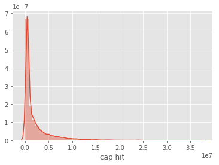

```python
# seeing the distribution of the cap hits
plt.style.use('ggplot')
sns.distplot(player_team['cap hit'])
plt.show()
```

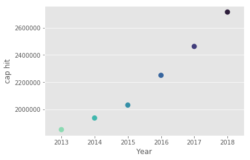

```python
#Trends of cap hit as the year progress
a = player_team.groupby(by='Year')['cap hit'].mean().to_frame()
a = a.reset_index()
a
plt.style.use('ggplot')
plt.figure()
sns.pointplot(x='Year', y='cap hit', ci=None,palette='mako_r', data=a)
plt.show()
```

Year-on-year the average cap hit has kept on increasing. The competition in recruiting good players and wrestling them from other teams has become more and more important over the last few years. This brings us to the first two questions.

#### 1. Does the overall spending (cap hit) of a team impact its win/loss percentage?

#### 2. What is the impact of spending on specific player position groups for the team? (Will my offense or defense define the win percentage during the year in terms of how much we need to spend on them?)

The absolute value of the cap hits is too large to clearly explain. We prefer viewing them in million dollars for our analysis. We are scaling it to improve how we can visualize our analysis.

```python
player_team['cap hit']=player_team['cap hit']/1000000
```

We realised that we can also get more information if we bring consistency between positions in both the player database and the drafts list. We decide to first bin the positions into offensive, defensive and special positions in our two DataFrames.

```python
#Determine and store the full name of each position in the drafts DataFrame
Drafts.insert(2,'Position_Group',np.NaN)
draft_pos1={'OT':'Offensive Tackle','CB':'Cornerback','OG':'Offensive Guard','P':'Punter','WR':'Wide Reciever','ILB':'Inside Linebacker','RB':'Running Back','DE':'Defensive End','QB':'Quarterback','DT':'Defensive Tackle','FB':'Fullback','OLB':'Outside Linebacker','FS':'Free Safety','K':'Kicker','C':'Center','TE':'Tight End','SS':'Strong Safety','LS':'Long Snapper','NT':'Nose Tackle','EDGE':'Defensive End','S':'Safety','LB':'Linebacker','DB':'Defensive back','OL':'Offensive Line'}
for i in range(len(Drafts.Player)):
    Drafts.loc[i,'Position_Group']=draft_pos1[Drafts.loc[i,'Pos']]
#Bin the positions into Offense, Defense and Special positions for Drafts
Drafts.insert(2,'Position',np.NaN)
draft_pos2={'Offensive Tackle':'Offense','Cornerback':'Defense','Offensive Guard':'Offense','Punter':'Special Positions','Wide Reciever':'Offense','Inside Linebacker':'Defense','Running Back':'Offense','Defensive End':'Defense','Quarterback':'Offense','Defensive Tackle':'Defense','Fullback':'Offense','Outside Linebacker':'Defense','Free Safety':'Defense','Kicker':'Special Positions','Center':'Offense','Tight End':'Offense','Strong Safety':'Defense','Long Snapper':'Special Positions','Nose Tackle':'Offense','Defensive End':'Defense','Safety':'Defense','Linebacker':'Defense','Defensive back':'Defense','Offensive Line':'Offense'}
for i in range(len(Drafts.Player)):
    Drafts.loc[i,'Position']=draft_pos2[Drafts.loc[i,'Position_Group']]
```

```python
#Bin the positions into Offense, Defense and Special positions for the player and team database
player_team.insert(28,'Position_Group',np.NaN)
pos_dict={'Quarterback':'Offense','Guard':'Offense','Wide Receiver':'Offense','Right Tackle':'Offense','Tight End':'Offense','Left Tackle':'Offense','Center':'Offense','Running Back':'Offense','Fullback':'Offense','Tackle':'Offense','III Quarterback':'Offense','Jr. Wide Receiver':'Offense','II Running Back':'Offense','Defensive Tackle':'Defense','Inside Linebacker':'Defense','Cornerback':'Defense','Outside Linebacker':'Defense','Safety':'Defense','Free Safety':'Defense','Strong Safety':'Defense','Defensive End':'Defense','Linebacker':'Defense','Jr. Defensive End':'Defense','Jr. Inside Linebacker':'Defense','III Safety':'Defense','III Free Safety':'Defense','Kicker':'Special Positions', 'Long Snapper':'Special Positions', 'Punter':'Special Positions', 'Kick Returner':'Special Positions','Jr. Tackle':'Offense'}
for i in range(len(player_team.Year)):
    player_team.loc[i,'Position_Group']=pos_dict[player_team.loc[i,'Position']]
```

Let's view the year wise average cap hit across teams for each of the years for each of the position groups and then for each of the teams across the years.

```python
#Yearwise average cap hit for each group
table = player_team.pivot_table(index='Position_Group', columns='Year', values='cap hit', aggfunc='mean', fill_value=0).astype(float)
table
```

| Year Position_Group | 2013 | 2014 | 2015 | 2016 | 2017 | 2018 |
| --- | --- | --- | --- | --- | --- | --- |
| Defense | 1.825864 | 1.876534 | 2.026657 | 2.156005 | 2.387757 | 2.592293 |
| Offense | 1.949376 | 2.088765 | 2.134154 | 2.450697 | 2.666651 | 2.999433 |
| Special Positions | 1.246116 | 1.225088 | 1.241067 | 1.371563 | 1.389765 | 1.395094 |

As it was before, on an average for each of the years and the position groups the average cap hit has consistently increased. No particular group stands out or has actually become significantly more important than the others, though special positions have increased the least at about an average of 150,000 dollars.

```python
#Team wise average cap hit for each group
table1 = player_team.pivot_table(index='Position_Group', columns='TeamShort', values='cap hit', aggfunc='mean', fill_value=0)
table1= table1.T
table1.reset_index(inplace=True)
#Obtain team wise average win/loss%
group1 = player_team.groupby(by='TeamShort')['Win/Loss%'].mean().to_frame()
group1.reset_index(inplace=True)
#Obtain team wise average cap hit
group2 = player_team.groupby(by='TeamShort')['cap hit'].mean().to_frame()
group2.reset_index(inplace=True)
#merge the two dataframes
group3 =pd.merge(group1,group2)
#View the win loss and average cap hit comparing them with that for each position group against the overall
group3 = pd.merge(group3,table1)
group3
```

|  | TeamShort | Win/Loss% | cap hit | Defense | Offense | Special Positions |
| --- | --- | --- | --- | --- | --- | --- |
| 0 | 49ers | 0.377595 | 1.924425 | 1.591699 | 2.348520 | 1.477929 |
| 1 | Bears | 0.397493 | 2.243579 | 1.994331 | 2.666313 | 1.195464 |
| 2 | Bengals | 0.548373 | 2.489768 | 2.691484 | 2.388956 | 1.643284 |
| 3 | Bills | 0.471704 | 2.046158 | 2.361947 | 1.871269 | 0.930300 |
| 4 | Broncos | 0.595997 | 2.351816 | 2.461251 | 2.392978 | 1.166273 |
| 5 | Browns | 0.233829 | 2.020538 | 2.046428 | 2.090942 | 1.071963 |
| 6 | Buccaneers | 0.322072 | 2.260037 | 2.397566 | 2.234284 | 1.270375 |
| 7 | Cardinals | 0.543599 | 2.152278 | 2.164921 | 2.268482 | 1.120233 |
| 8 | Chargers | 0.487507 | 2.191786 | 1.890403 | 2.625531 | 1.263643 |
| 9 | Chiefs | 0.675705 | 2.351235 | 2.565251 | 2.236765 | 1.574510 |
| 10 | Colts | 0.540799 | 2.007512 | 1.784520 | 2.242640 | 2.126875 |
| 11 | Cowboys | 0.581928 | 2.135879 | 1.804593 | 2.578219 | 1.425324 |
| 12 | Dolphins | 0.467012 | 2.149516 | 2.272705 | 2.160041 | 0.896020 |
| 13 | Eagles | 0.584107 | 2.351287 | 2.155881 | 2.748165 | 0.873242 |
| 14 | Falcons | 0.476950 | 2.344935 | 1.814304 | 2.991503 | 1.547060 |
| 15 | Giants | 0.389935 | 1.997250 | 2.024771 | 2.095085 | 0.977273 |
| 16 | Jaguars | 0.308561 | 2.168675 | 2.478055 | 2.023216 | 0.989023 |
| 17 | Jets | 0.372950 | 2.118563 | 2.106545 | 2.274506 | 0.967182 |
| 18 | Lions | 0.511120 | 2.256786 | 2.048250 | 2.580218 | 1.447370 |
| 19 | Packers | 0.558186 | 2.416084 | 2.360500 | 2.585073 | 1.511845 |
| 20 | Panthers | 0.603871 | 2.218656 | 2.078320 | 2.453949 | 1.477784 |
| 21 | Patriots | 0.770190 | 2.226722 | 1.996234 | 2.488703 | 1.988694 |
| 22 | Raiders | 0.370073 | 2.122092 | 1.828667 | 2.472961 | 1.706540 |
| 23 | Rams | 0.497115 | 2.270746 | 2.597664 | 2.076987 | 1.249456 |
| 24 | Ravens | 0.516746 | 2.079669 | 2.017403 | 2.167829 | 1.909352 |
| 25 | Redskins | 0.402806 | 2.115169 | 1.822170 | 2.557503 | 0.849157 |
| 26 | Saints | 0.579418 | 2.050875 | 1.588869 | 2.575848 | 1.802489 |
| 27 | Seahawks | 0.669856 | 2.331720 | 2.539895 | 2.237733 | 1.087637 |
| 28 | Steelers | 0.649445 | 2.315208 | 2.094746 | 2.734558 | 0.897971 |
| 29 | Texans | 0.450712 | 2.196407 | 2.331002 | 2.172802 | 1.045122 |
| 30 | Titans | 0.393610 | 2.265923 | 2.359681 | 2.220438 | 1.847393 |
| 31 | Vikings | 0.550655 | 2.454791 | 2.426131 | 2.682562 | 0.854199 |

Let's visualize how the win/loss ratio is distributed with the average cap hit across teams and for each of the positions.

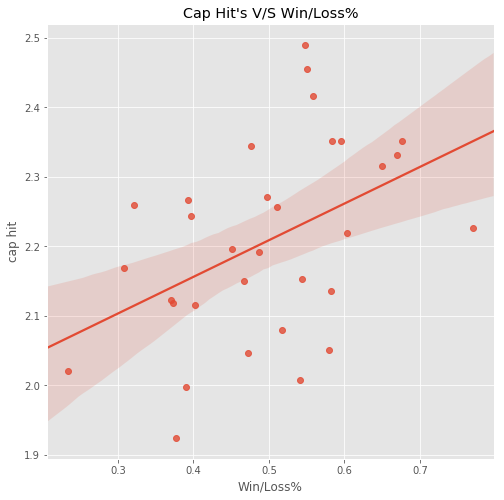

```python
#Use the function regplot to make a scatterplot
plt.figure(figsize=(8,8))
plt.title("Cap Hit's V/S Win/Loss%")
sns.regplot(x=group3['Win/Loss%'], y=group3['cap hit'])
plt.show()
```

From our plot, we observe the relationship that the cap hit has with the win/loss percentage. As the teams increase their spending, the actual win/loss % does go up. This means that spending money to recruit new players does help improve performance. We are further evaluating if any particular position groups from Offense, Defense or Special Positions impacts the win/loss ratio.

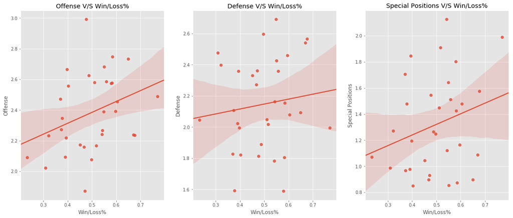

```python
#Plot the relationships for each of the position groups with the win/loss ratio
plt.figure(figsize=(20,8))
plt.subplot(1,3,1)

sns.regplot(x=group3['Win/Loss%'], y=group3.Offense)
plt.title("Offense V/S Win/Loss%")

plt.subplot(1,3,2)

sns.regplot(x=group3['Win/Loss%'], y=group3.Defense)
plt.title("Defense V/S Win/Loss%")
plt.subplot(1,3,3)

sns.regplot(x=group3['Win/Loss%'], y=group3['Special Positions'])
plt.title("Special Positions V/S Win/Loss%")
plt.show()
```

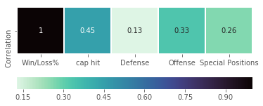

```python
#Plot the absolute correlations
a = group3.iloc[:,1:].corrwith(group3.iloc[:,1]).to_frame().T
a.index= ['Correlation']
a
sns.heatmap(a, cmap='mako_r', annot=True, square=True, linewidths=1,cbar_kws={'orientation':'horizontal'});
```

From amongst our three groups, spend on offense has the most impact on the win/loss ration as compared to the other two. The least impact comes from the Defense. The plot above validates the individual scatter plots indicating the relationship with each of the groups. However, the impact on cap hit is not significant, all three of our groups and on an overall basis, increase in the cap hit does help improve the win/loss ratio.

Since the impact of spend on offensive positions is the most, we dig deeper into the cap hit of offensive players. Let's group some of the positions and observe if that gives us a better picture of our analysis. We broadly group them into their positional names rather than specifics and view their impact on the win/loss ratio.

```python
#Group the positions into more groups
player_team.insert(29,'New_Position_Group',np.NaN)
succ_pos={'Quarterback':'Quarterback','Guard':'Guard','Wide Receiver':'Receiver','Right Tackle':'Tackle','Tight End':'End','Left Tackle':'Tackle','Center':'Center','Running Back':'Running Back','Fullback':'Running Back','Tackle':'Tackle','III Quarterback':'Quarterback','Jr. Wide Receiver':'Receiver','II Running Back':'Running Back','Defensive Tackle':'Tackle','Inside Linebacker':'Linebacker','Cornerback':'Cornerback','Outside Linebacker':'Linebacker','Safety':'Safety','Free Safety':'Safety','Strong Safety':'Safety','Defensive End':'End','Linebacker':'Linebacker','Jr. Defensive End':'End','Jr. Inside Linebacker':'Linebacker','III Safety':'Safety','III Free Safety':'Safety','Kicker':'Kicker', 'Long Snapper':'Long Snapper', 'Punter':'Punter', 'Kick Returner':'Kicker','Jr. Tackle':'Tackle'}
for i in range(len(player_team.Year)):
    player_team.loc[i,'New_Position_Group']=succ_pos[player_team.loc[i,'Position']]
```

```python
#Group the drafts positions into more groups
Drafts.insert(4,'New_Position_Group',np.NaN)
drafts_new_pos={'Offensive Tackle':'Tackle','Cornerback':'Cornerback','Offensive Guard':'Guard','Punter':'Punter','Wide Reciever':'Receiver','Inside Linebacker':'Linebacker','Running Back':'Running Back','Defensive End':'End','Quarterback':'Quarterback','Defensive Tackle':'Tackle','Fullback':'Running Back','Outside Linebacker':'Linebacker','Free Safety':'Safety','Kicker':'Kicker','Center':'Center','Tight End':'End','Strong Safety':'Safety','Long Snapper':'Long Snapper','Nose Tackle':'Tackle','Defensive End':'End','Safety':'Safety','Linebacker':'Linebacker','Defensive back':'Linebacker','Offensive Line':'Center'}
for i in range(len(Drafts.Position)):
    Drafts.loc[i,'New_Position_Group']=drafts_new_pos[Drafts.loc[i,'Position_Group']]
```

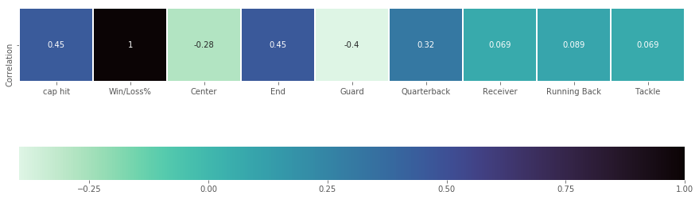

```python
#View the correlation plot between the cap hit for these group positions and the win-loss ratio
new=group3[['TeamShort','cap hit','Win/Loss%']]
offense = player_team[player_team['Position_Group']=='Offense']
table3 = offense.pivot_table(index='New_Position_Group', columns='TeamShort', values='cap hit', aggfunc='mean', fill_value=0)
table3= table3.T
table3.reset_index(inplace=True)
offense_spend2 = pd.merge(new,table3)
c = offense_spend2.iloc[:,1:].corrwith(offense_spend2.iloc[:,2]).to_frame().T
c.index= ['Correlation']
plt.figure(figsize=(15,10))
sns.heatmap(c, cmap='mako_r', annot=True, square=True, linewidths=1,cbar_kws={'orientation':'horizontal'});
```

Barring four primary position groups (Center, End, Guard and Quarterback), all the other positions seem to have minimal impact on the win/loss ratio. However, it is interesting to see that spending on a Center or a Guard has a negative impact on the success of teams.  
We next look at the position wise mean cap hit to better understand their correlation with the win loss percentage.

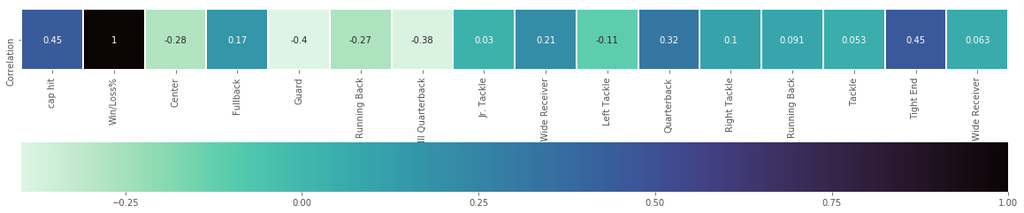

```python
#View the correlation for cap hits for offensive positions
offense = player_team[player_team['Position_Group']=='Offense']
table2 = offense.pivot_table(index='Position', columns='TeamShort', values='cap hit', aggfunc='mean', fill_value=0)
table2= table2.T
table2.reset_index(inplace=True)
offense_spend = pd.merge(new,table2)
b = offense_spend.iloc[:,1:].corrwith(offense_spend.iloc[:,2]).to_frame().T
b.index= ['Correlation']
b
plt.figure(figsize=(20,10))
sns.heatmap(b, cmap='mako_r', annot=True, square=True, linewidths=1,cbar_kws={'orientation':'horizontal'});
```

We can view specific positions above where and how spending on them impacts the win/loss ratio. It gives us a view where spending on a particular position is advisable as against another i.e. spending more on a player in the Tight End will have a more positive impact as compared to spending more on a Running Back. A team can therefore better plan their spending and allocate funds according to positions that would help their cause than hurt it.

#### Conclusions

We can see that the positional spending does impact the win/loss record in different aspects. More importantly spending on a particular position may not necessarily mean that it will help improve the win/loss ratio, but we would still need those positions for the team to play well. It would be best to spend lesser amount of the cap hit on these positions and groups as compared to a more important group like a Quarterback. We have a better perspective of which group can be valued more.

# Predictive Analysis

#### 3. If a player with certain demographics is drafted to a particular team, depending on his position how much is he likely to cost the team?

The next process in our analysis is to achieve our objective of being able to determine how much a team should spend on drafting a new recruit. For every player, who is drafted we have available their demographics and their position. Further, we also have the teams these players were drafted to according to their years. We will run a regression to determine the value of cap hit that a team can afford for a player with these demographics based on the current pay scales in the NFL. We can accordingly view this for new players for different teams and years.

```python
#We want to identify our prediction variables and dependent variables from our training database
success_train_x=player_team[['Year','TeamShort','Wt','Ht (Inch)','New_Position_Group']]
success_train_y=player_team[['cap hit']]
```

```python
#We want to determine our input details for drafts
success_test=Drafts[['Year','TeamShort','Wt','Ht (Inch)','New_Position_Group']]
```

```python
#We delete the players who do not have a defined team in our draft data set and also the index column
success_test=success_test.dropna(subset=['TeamShort'])
success_test=success_test.reset_index().drop('index',axis=1)
```

```python
#We convert all of our categorical data into a matrix to use in our regressional analysis
cols=['Year','TeamShort','Wt','Ht (Inch)','New_Position_Group']
cat_cols=['TeamShort','New_Position_Group']
train_dummies=pd.get_dummies(success_train_x[cols],columns=cat_cols,prefix='', prefix_sep='', drop_first=True)
test_dummies=pd.get_dummies(success_test[cols],columns=cat_cols,prefix='', prefix_sep='', drop_first=True)
```

```python
#We want to validate our model before we are able to run it on unknown values, for that we split it into testing and validation sets
from sklearn.model_selection import train_test_split
X_train, X_test, y_train, y_test = train_test_split(train_dummies, success_train_y, test_size=0.2, random_state=101)
```

#### Linear Regression Model

```python
#Import the linear regression function from the sci-kit learn package and obtain a model that fits the data from the player database
from sklearn.linear_model import LinearRegression
lm = LinearRegression()
lm.fit(X_train,y_train['cap hit'])
```

```
LinearRegression(copy_X=True, fit_intercept=True, n_jobs=1, normalize=False)
```

```python
#Predict the output and project it onto our validation set
predictions = lm.predict(X_test)
#View the mean squared error of our model
from sklearn.metrics import mean_squared_error
mean_squared_error(y_test,predictions)
```

```
8.89429102567654
```

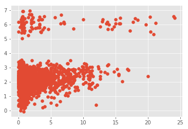

```python
#Display how our predictions stand against the actual values
plt.scatter(y_test,predictions)
plt.show()
```

#### Poission Regression Model

```python
#Prepare the data to run a poisson regression
feat_cols =list(X_train.columns)
X = [elem for elem in X_train[feat_cols].values]
X = sm.add_constant(X, prepend=False)
Y = [elem for elem in y_train['cap hit'].values]
```

```python
#Prepare and print a poission regression
poisson_mod = sm.Poisson(Y, X)
poisson_res = poisson_mod.fit(method="newton")
```

```
Optimization terminated successfully.
         Current function value: 2.379926
         Iterations 9
```

```python
#Lets prepare our validation set the same way we prepared our training set
Xtest = [elem for elem in X_test[feat_cols].values]
Xtest = sm.add_constant(X_test, prepend=False)
Y_test = [elem for elem in y_test['cap hit'].values]
```

```python
#Predict the values from our validation data using poisson regression and observe the mean squared error
predVals = poisson_res.predict(Xtest)
mean_squared_error(y_test,predVals)
```

```
8.930146167586702
```

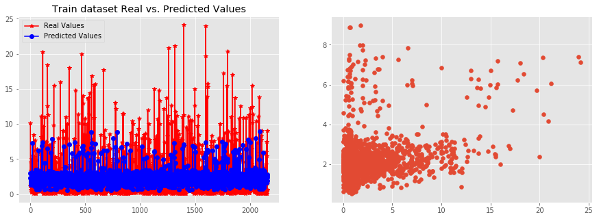

```python
#Plot our predictions
plt.figure(figsize=(15,5))
plt.subplot(1,2,1)
plt.plot(range(len(Y_test)), Y_test, 'r*-', range(len(Y_test)), predVals, 'bo-')
plt.title('Train dataset Real vs. Predicted Values')
plt.legend(['Real Values', 'Predicted Values'])
plt.subplot(1,2,2)
plt.scatter(Y_test,predVals)
plt.show()
```

We can see that either of our models performs similarly and we can use either of them predict the maximum value that a team should take as cap hit for a player. Alternatively they can choose whichever one they prefer as the value they feel appropriate to determine their upper cutoff.

### Sample Predictions

We predict for a particular sample across both models to test the impact of our models in actually predicting the cap hit for players who haven't had any values for them.

```python
success_test.iloc[1250,:]
```

```
Year                     2018
TeamShort             Falcons
Wt                        314
Ht (Inch)                  72
New_Position_Group     Tackle
Name: 1250, dtype: object
```

```python
draft_sample=test_dummies.iloc[1250,:]
print(lm.predict(draft_sample.values.reshape(1,-1))[0].round())
```

```
3.0
```

```python
draft_sample2=test_dummies
draft_sample2 = [elem for elem in draft_sample2[feat_cols].values]
draft_sample2 = sm.add_constant(draft_sample2, prepend=False)
sample_predict=poisson_res.predict(draft_sample2)
print(sample_predict[1250].round())
```

```
3.0
```

## Overall Conclusions

From our data that we have scraped, we are able to a variety of correlations between positional spending and the win/loss ratio of a team. We can understand that there a lot of teams who spend on players across different positions and some times may go overboard and those players may not bring justice to the spending of those teams. It is ideal that the teams have a guide for how much they should restrict their spending to for a particular set of players in a position. We can help them do that with this data though there are other metrics that they may consider including the past history of these players at the college level, their current form and if spending excessively on a new draft will give them the returns they want. Also, a new draft and the possible oppurtunity of an improved win/loss ration due to increased spending may not necessarily translate into financial success for the teams and this can and will be further evaluated.